# NEPA Decarbonization Technology Analysis: Deliverable 2

Determinations of Significance Across Resource Areas

Published

September 26, 2026

This report delivers:

> Determinations of significance across resource areas; factors that contribute to a determination of “significant impact,” starting with mitigated FONSIs.

## Context

When a decarbonization project such as a solar farm or a transmission line needs federal approval, the lead agency (here, BLM or the Department of Energy) studies its environmental impact and determines whether that impact is “significant.”

That one determination carries weight. If the agency finds the impact not significant, the project moves ahead on a faster track, documented in a Finding of No Significant Impact (FONSI). If it finds the impact significant, that triggers a longer and more demanding review.

Often the agency lands in between, concluding that an impact would be significant unless the developer commits to specific measures to reduce it. That is a mitigated finding, and it is the most revealing case, because it shows the exact line the agency drew and what it required to stay below it.

So this deliverable answers, across these decarbonization projects, how agencies decide what counts as “significant” in each environmental area (air, water, wildlife, cultural sites, and so on), and what mitigation they require to avoid that label. Answering it means coding a judgment call out of thousands of dense decision documents, more than could be reviewed by hand. The workflow below describes how we do that reliably.

## Workflow

The approach pairs the scale of automation with the reliability of human judgment: software and AI do the reading at a scale no person could, while analysts define the scope, hold the checkpoints, and grade the AI against their own answer key before any result counts.

1 · Scope

Two document tracks: decarbonization **FONSIs** led by BLM or the DOE family (258 documents across 193 projects, each dated to its regulatory era) and final **EISs** from every lead agency (1,082 documents across 506 projects)

↓

2 · Gather documents

Pull the FONSI and supporting EA documents — and, on the EIS track, the final EIS impact chapters — from the NEPATEC 2.0 corpus, then use text-pattern (regex) rules to locate the specific sections where significance findings live

↓

3 · Extract the judgment calls

**Automated:** the flagged passages go to Claude (Sonnet 5), which codes each one — outcome, resource area, threshold, mitigation.  
**In parallel — the answer key:** two AI coders independently label a 400-passage sample per track (FONSI and EIS) and a human adjudicator settles every disagreement

↓

4 · Validate

Score the AI against the held-out human labels on each track (class agreement 0.81 FONSI, 0.69 EIS) before any result counts

↓

5 · Analyze and report

Validated findings become this report and a source-linked data table — every number traces to its page

The five steps of the analysis — each card matches a numbered step below.

## What the FONSIs and EISs tell us

A significance call can land on either side of the line, and the two document types record opposite outcomes, so we analyze them separately rather than pool them. FONSIs are the below-the-line record: the agency concluded the impact is not significant, and this is where the mitigated cases live, the impacts that would have been significant without committed measures. FONSIs show how agencies stay under the line and what they require to get there. EISs are the above-the-line record: impacts the agency judged significant, and at the extreme, significant and unavoidable. They tell us which resources actually cross the line.

The diagram below is the vocabulary the rest of this report uses — every determination lands in one of these outcomes, and “the line” is the significance threshold that separates them:

Significant and unavoidable

The impact is significant and **no available measure** can bring it below the threshold.

Significant adverse

The impact crosses the significance threshold.

THE SIGNIFICANCE LINE

Less than significant with committed mitigation

The impact **would** cross the line, but specific required measures pull it under — the **mitigated FONSI**. These sit right at the line and are this report's central subject.

Less than significant

A real but minor impact that stays under the line without mitigation measures.

No impact

The agency finds no meaningful impact on the resource at all — the below-the-line default.

EIS

FONSI

The brackets show where each outcome is recorded: above-the-line findings in an **EIS**, below-the-line in a **FONSI** — and a less-than-significant-with-committed-mitigation call appears in both (the mitigated FONSI below the line; its EIS analog is a significant impact judged reducible). Boxes closer to the line are closer calls.

Figure 1 sets the scale: the decarbonization universe splits into a larger EIS corpus and a smaller FONSI corpus (top), and both tracks touch every major resource area (bottom).

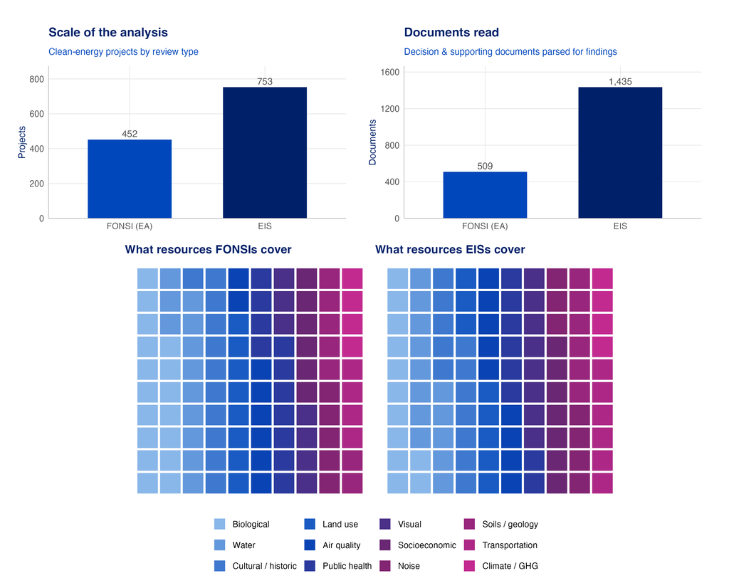

Figure 1: Top: the analysis scale, by review type — projects (left) and the documents actually parsed for findings (right); the EIS corpus is the larger one. Bottom: the mix of resource areas the determinations cover, for FONSIs (left) and EISs (right); each square ≈ 1% of that track’s determinations. Both waffles share the resource legend.

## FONSI analysis

The decarbonization FONSI corpus contains 452 projects. This analysis rests on the 193 of them that are (a) led by BLM or the DOE family and (b) carry machine-extractable significance findings — spanning 258 decision documents and 1,990 distinct significance determinations (one per document × resource area × outcome).

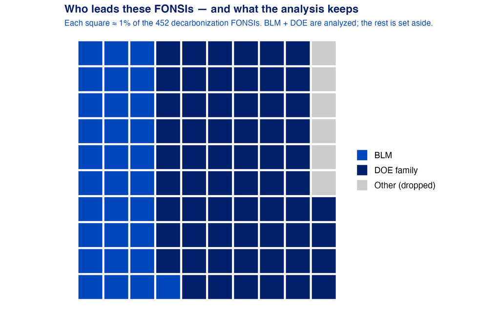

Figure 2: Lead agency for the 452 decarbonization FONSIs. BLM and the DOE family (94.5%) carry the headline analysis; the remaining 5.5% — led by other federal agencies with only partial coverage — are set aside as context.

Three filters take the 452 down to the 193 analyzed here, and Figure 3 traces each step:

1. **Agency scope (452 → 427).** The 25 FONSIs led by agencies other than BLM and the DOE family are set aside as context (Figure 2); only BLM + DOE have complete coverage in the dataset.
2. **A dated, 2009-or-later decision (427 → 261), the largest cut.** NEPA’s ground rules changed repeatedly over this period, most recently with the 2023 Fiscal Responsibility Act, and comparing agency behavior across those regimes is one of this deliverable’s core questions, so every rate is read against the regulatory era the decision was made under. A FONSI with no extractable decision date (105 projects) cannot be assigned an era, pre-2009 decisions (55) predate the consistently documented modern corpus, and 6 sit on a regime boundary.
3. **Extraction coverage (261 → 193).** The upstream pipeline locates the finding sections in 224 of the 261 (the other 37 documents were parsed but phrase their finding in wording the extraction does not recognize), and in 31 more, the flagged text turns out to contain no codable determination.

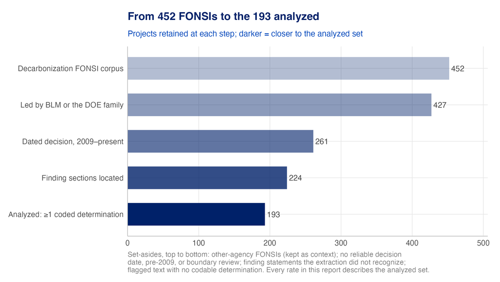

Figure 3: How the 452-project FONSI corpus narrows to the 193 analyzed: agency scope, then the dated 2009–present window, then extraction coverage. Darker bars are closer to the analyzed set; every rate in this report describes the darkest bar.

**TipKey takeaways (FONSI track)**

- **Most analyzed decarbonization FONSIs are mitigated.** About 58% of the 258 analyzed FONSI decision documents — the BLM + DOE, dated, machine-extractable set traced in Figure 3, not all 452 in the corpus — reach “no significant impact” only because the developer commits to specific measures; the impact would have been significant otherwise.
- **A handful of resources carry the mitigation.** Biological resources, soils/geology, water, and cultural/historic sites are where projects most often sit at the line and are pulled under it — biological alone is mitigation-dependent in ~30% of its determinations.
- **The below-the-line default is “no significant impact.”** Across resource areas, outright no-significant-impact is the most common outcome; genuinely significant findings live in the EIS record, not here.
- **The numbers are validated.** The extraction agrees with an AI-human reviewed answer key at 0.81 on the significance class (held-out test) before any figure in this report was produced.

### Extraction accuracy

Every determination is machine-extracted, so before any number is reported the pipeline is scored against an AI-human reviewed answer key[^1]. The sample is 400 windows (a “window” is one flagged passage the extraction reads), drawn stratified, meaning it deliberately covers every outcome type and the agency mix rather than being a simple random draw, plus negative passages to catch false positives. 30% of the windows were held out as an untouched test, and the held-out column is the score we rely on.

Table 1: Extraction accuracy versus the AI-human reviewed gold set, full sample and held-out test.

| What the pipeline is scored on | All 400 | Held-out test |
| --- | --- | --- |
| Finds a determination (per passage) | 0.97 | 0.98 |
| Assigns the right resource | 0.88 | 0.89 |
| Gets the significance class right | 0.78 | 0.81 |
| Flags mitigation-dependence (screen) | 0.62 | 0.58 |
| Identifies the regulatory threshold | 0.71 | 0.66 |

Scores are F1 (0–1), except the threshold row, which is accuracy. Held-out = the 30% of the gold set the pipeline never influenced.

The extraction rarely misses a determination and places it in the right resource area ~89% of the time; it agrees with the answer key on the significance class at 0.81, the standard bar for this kind of task. The one weaker signal is mitigation-dependence, discussed at the end of this section.

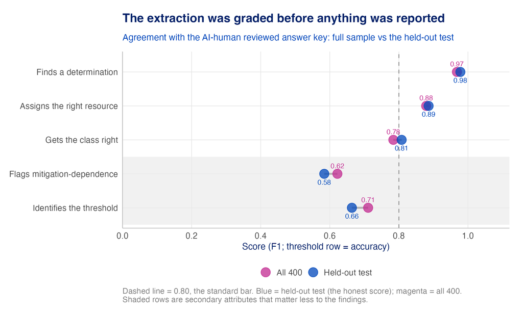

Figure 4: Agreement with the AI-human reviewed answer key on the stratified 400-window sample (one window = one flagged passage; sampled to cover every outcome type and the agency mix): full sample in magenta versus the untouched 30% held-out test in blue. The dashed line marks 0.80, the standard bar for this kind of task.

Why the last two scores are lower, and why it doesn’t undercut the findings: both are secondary attributes, not the core call, and both are genuinely harder.

- Mitigation-dependence (0.58–0.62) is a screening metric, not a reported number. Deciding whether a conclusion depends on committed mitigation is one of the hardest judgments in the whole task: the two independent AI coders themselves agreed only ~68% of the time on the fine line between “less than significant” and “less than significant with mitigation.” This flag is used to screen candidates; in this pass it was tightened (requiring a real same-resource overlap plus at least two committed conditions), which lifted it to F1 0.62 overall / 0.58 held-out (precision 0.53 / 0.48) against the gold. The resource-level mitigation numbers below do not rest on this screen; they come from the high-precision per-resource class signal and a separately validated condition→resource join (discussed at the end of this section).
- Regulatory threshold (0.66–0.71) is the most granular field, pinning a conclusion to a specific rule (a NAAQS limit, an ESA take threshold, a §106 adverse-effect finding). Many conclusions are not anchored to a single numeric threshold at all, and the distinctions are fine. It is reported descriptively as supporting context, never as a headline number.

The three scores that carry the findings — finding the determination, placing the resource, and getting the significance class — all clear or approach the standard bar.

### How agencies stay below the line

Within FONSIs, the determinations sit — almost without exception — below the significance line: the agency either finds no significant impact outright or an impact that is less than significant, sometimes only with committed mitigation.[^2] Figure 5 breaks this down by resource area — each resource’s determinations split across the three outcomes, sorted so the resources most reliant on mitigation sit at the top, with the count and share behind each bar.

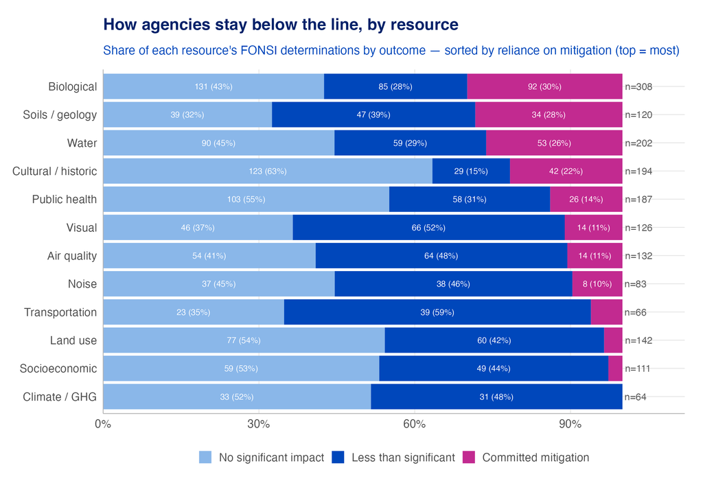

Figure 5: Share of each resource’s FONSI determinations by outcome, sorted by reliance on mitigation. Each segment shows its count and percentage; n is the resource’s total determinations. Resources with more magenta lean harder on committed mitigation to reach a not-significant finding.

The dominant outcome is no significant impact, as expected for FONSIs. But the resources agencies analyze most — biological, water, cultural/historic, and public health — are also where the close calls concentrate: the magenta band (committed mitigation) is widest for biological, soils/geology, and water. That is what makes the mitigated cases the real story.

### Regulatory thresholds behind the determinations

When a conclusion is anchored to a specific regulatory yardstick, which one? Figure 6 profiles the thresholds the FONSI conclusions cite — dominated by quantitative numeric limits (resource-specific caps and standards), wetland/floodplain extent, NHPA §106 adverse-effect findings for cultural resources, visual (VRM) classes, and the Endangered Species Act (take and jeopardy). This mirrors the resource pattern above: the same areas that drive mitigation are the ones with the hardest regulatory lines to clear.

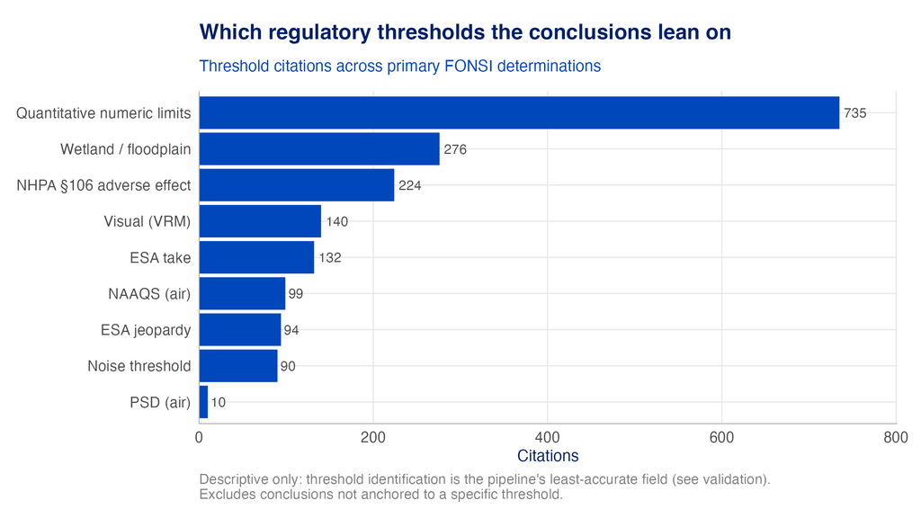

Figure 6: Regulatory thresholds cited across primary FONSI determinations. Reported descriptively: identifying the exact threshold is the pipeline’s least-accurate field, and many conclusions are not anchored to a specific threshold at all.

Threshold identification is the extraction’s weakest field (see the validation above), so treat this profile as an indicative picture of which rules recur, not an exact census.

### Mitigated FONSIs

The most revealing determinations are the mitigated ones: impacts the agency says would be significant, brought below the line only by required measures. These show exactly where the line sits and what it costs to stay under it, and they are the majority of FONSIs (Figure 7).

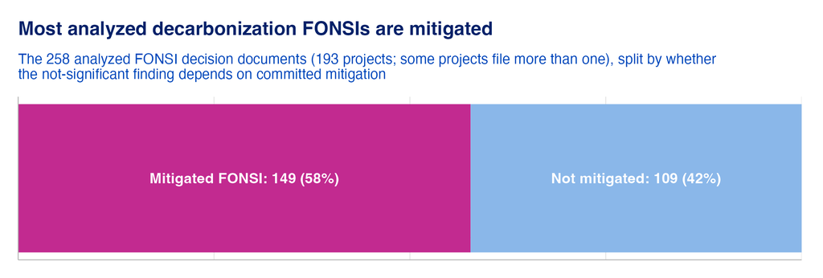

Figure 7: Share of FONSI documents that reach a not-significant finding only with committed mitigation (per-resource class signal).

About 58% of the analyzed FONSI documents are mitigated — at least one resource whose not-significant conclusion depends explicitly on committed mitigation. The denominator is documents, not projects: the analyzed set is 258 decision documents across 193 projects (some projects file more than one FONSI), so the figure’s counts (149 mitigated + 109 not) sum to 258.

The mitigation burden is concentrated in Biological (30%), Soils / geology (28%), Water (26%), Cultural / historic (22%), the resources most often needing committed measures to keep a project below the significance line. That pattern is the deliverable’s core finding: biological, soils/geology, water, and cultural resources are where decarbonization projects most frequently sit at the line and are pulled under it by mitigation.

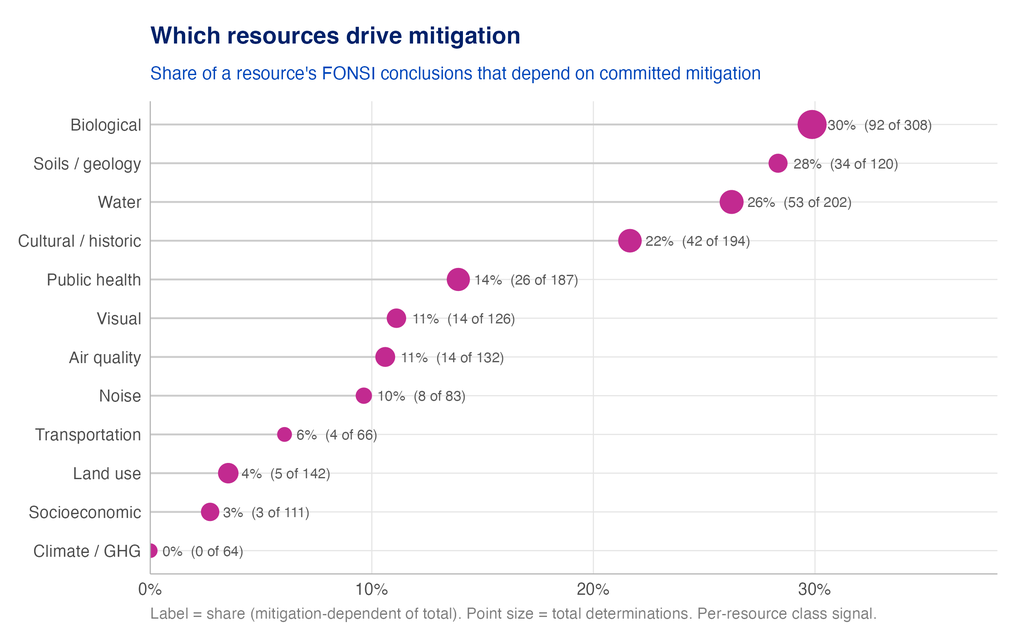

Figure 8: Share of a resource’s FONSI conclusions that depend on committed mitigation (per-resource class signal). Point size scales with how often the resource is analyzed.

Reading volume and mitigation-intensity together sharpens the picture. Resources in the upper right are both analyzed often and mitigated often, the areas that most shape whether a decarbonization project can take the faster FONSI path.

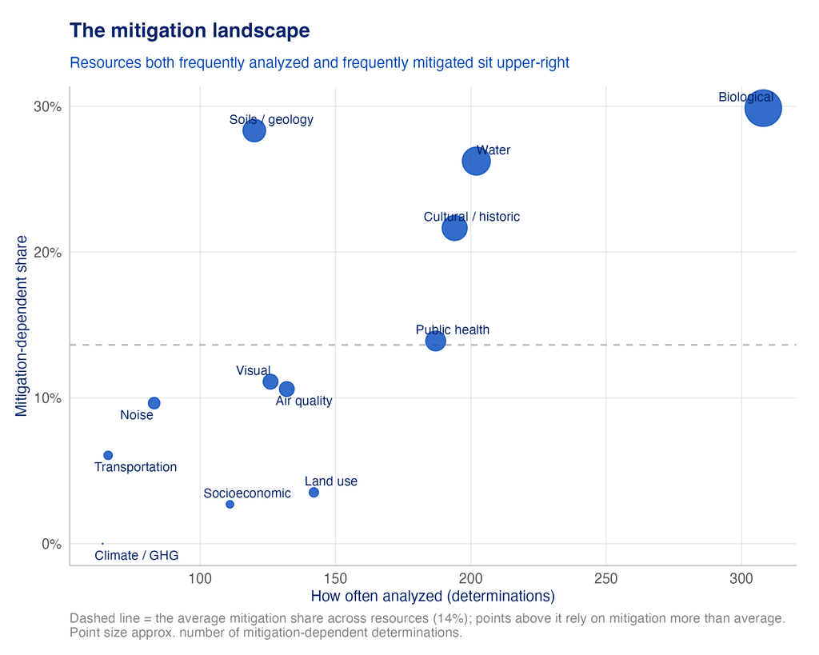

Figure 9: Each resource by how often it is analyzed (x) and how often its conclusion depends on mitigation (y). Biological resources dominate both; soils/geology are mitigated intensively despite lower volume. Dashed line = overall average mitigation share.

What do these mitigations actually look like across the board? Two verbatim examples per resource, ordered from the most mitigation-heavy resources down — seasonal timing and species avoidance for biology, wetland minimization for water, cultural-resource protection measures, dust control for air, and so on:

Table 2: Representative mitigation measures behind less-than-significant-with-mitigation conclusions, by resource area.

| Example mitigation drawn from the FONSI |
| --- |
| Biological |
| Restricting construction to August/September is intended to mitigate potential nest failure and displacement effects on Red-throated Loons. |
| Potential impacts to desert kit fox would be avoided through compliance with general avoidance and mitigation measures identified in Appendix G. |
| Soils / geology |
| Use of BMPs and implementation of a construction SWPPP would ensure that short-term soil erosion and sediment transport impacts remain minor. |
| Soil erosion potential is limited by flat topography and controlled on-site via compliance with mitigation in Appendix B, resulting in a minor impact. |
| Water |
| Wetlands in the area were inventoried and potential impacts were mitigated in the design of the Proposed Action alternative. |
| Impacts to wetlands would be low, with only 0.01 acre of permanent wetland fill from structure replacement activities and impact minimization measures applied. |
| Cultural / historic |
| KSU committed to minimize or avoid potential effects to cultural resources via protection measures detailed in section 2.5 of the EA. |
| The PV array at Lakehurst may result in indirect visual effects to the LTA Historic District, but appropriate landscaping would minimize this effect. |
| Public health |
| With mitigation measures and BMPs, fire-prevention measures and traffic management would prevent disruption to fire, police, and medical emergency services. |
| With BMPs in place for portable toilet sanitary services during construction and operation, potential impacts from sanitary discharges would be non-significant. |
| Visual |
| KSU committed to minimize or avoid potential effects to visual resources through protection measures in section 2.5 of the EA. |
| VRM impacts are minor and localized, mitigated to the greatest degree feasible through Appendix B measures and project-specific stipulations. |
| Air quality |
| Air quality impacts would be low, temporary, and would not violate air quality standards, with dust control mitigation minimizing construction impacts. |
| Construction would cause unavoidable minor air quality impacts, but standard pollution control equipment on construction vehicles would mitigate these minor impacts. |
| Noise |
| Construction noise would be discernable up to 2,000 feet but would be low to moderate and mitigated by limiting activities to daytime hours where feasible. |
| Construction noise from initial vegetation removal would not significantly affect sensitive receptors or conflict with noise guidelines due to implementation of PCMs and the short duration of activiti… |
| Transportation |
| KSU committed to minimize or avoid potential effects to transportation through the protection measures detailed in section 2.5 of the EA. |
| Traffic delays from construction and lane closures would be temporary, with traffic controllers used where appropriate to reduce impacts. |
| Land use |
| KSU committed to implement protection measures to minimize or avoid potential effects to land uses as detailed in section 2.5 of the EA. |
| Minor short- and long-term impacts to livestock grazing forage availability would not be significant with best management practices and mitigation measures. |
| Socioeconomic |
| Agricultural land disturbance would be temporary and mitigated by revegetation, scheduling around fallow periods, compensating landowners for crop loss, and maintaining fences/gates. |

Verbatim from the model's per-resource rationale on determinations that depend on committed mitigation. Climate/GHG had no such conclusions in the FONSI corpus.

Mitigated FONSIs are also broader analyses: a project that needs committed mitigation for any resource tends to address more resource areas overall — a median of roughly six versus four for non-mitigated FONSIs.

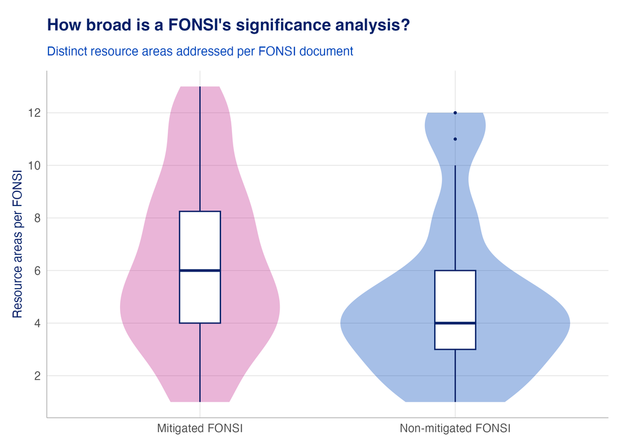

Figure 10: Distinct resource areas addressed per FONSI, split by whether the document relies on committed mitigation. Boxes show the median and interquartile range; the shaded shape is the full distribution.

### Matching each effect to a same-resource commitment

The mitigated-FONSI shares above read the model’s per-resource class judgment: did this conclusion land in the committed-mitigation class? A second, independent line of evidence comes from the documents’ own permit conditions. For each flagged effect we can look at the committed mitigation measures nearby (in the same section, or within a two-page window) and ask whether any of them addresses the same resource area. That is a direct join between an impact and a commitment, built on condition→resource tags that were rebuilt in July 2026 and are now independently validated (see the note below).

On that basis, 23% of the flagged significant / less-than-significant FONSI determinations are matched to at least one committed mitigation condition that addresses the same resource area: 222 of 974 determinations, under any-overlap matching. Read this as an aggregate map of which resources recurringly attract same-resource mitigation, not as a per-project ruling that each finding is legally mitigation-dependent; the match rule is deliberately inclusive (any-overlap), so it over-attributes at the individual-determination grain.

**How the pairing is validated.** The condition→resource tags this rests on were checked against an 80-row gold set (71 distinct projects) hand-labeled by an independent model agent, with an informal blind spot-check by a second reviewer that found no disagreements (not a persisted comparison artifact). Tag-level agreement is F1 0.83 and any-overlap accuracy 0.89, a large gain over the prior keyword tags (0.46). The one known bias in the gold runs in a single direction, inclusive multi-labeling, which slightly inflates measured match rates, so read the aggregate share as a mild over-count rather than a floor. One taxonomy boundary matters for the per-resource splits only: “sociocultural systems” commitments map to socioeconomic, not cultural, under the taxonomy’s narrow (historic / §106) definition of cultural resources — a documented, ratified reading that shifts the resource breakdown below but never the aggregate share.

Broken out by resource, the pairing concentrates in the same areas as the class signal, with Biological (44%), Water (33%), Air quality (22%), Cultural / historic (20%) leading. Treat these per-resource splits as directional only: exact per-resource attribution is weaker than the aggregate (condition-tag precision ≈0.76), so trust the ranking while reading any single resource’s percentage as approximate, not a census.

The stricter question, whether an individual conclusion legally depends on committed mitigation, is answered by a separate labeled screening metric, not by a reported share. It was tightened in this pass (a real same-resource overlap and at least two committed conditions) and now scores F1 0.62 overall / 0.58 held-out (precision 0.53 / 0.48) against the gold, up from 0.57 overall. It screens candidates; it is never a headline number.

### Variation by agency

The two departments run different kinds of projects — BLM tends toward land-based sites, the DOE family toward energy facilities and transmission — so the resources that push them to mitigate differ too. Figure 11 compares, for each resource, how often a conclusion depends on mitigation for BLM versus DOE.

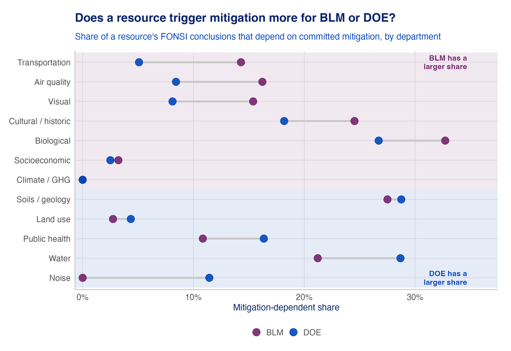

Figure 11: Share of each resource’s FONSI conclusions that depend on committed mitigation, BLM versus DOE (the department and its sub-agencies). A wider gap means the resource is a bigger mitigation driver for one department than the other.

The pattern is intuitive: biological, cultural/historic, air quality, and visual resources drive mitigation harder for BLM (land-facing impacts on habitat, historic sites, and viewsheds), while noise and water lean toward the DOE family (facility- and construction-driven effects). Within DOE, the picture varies further by sub-agency (Figure 12), though the smaller sub-agency cells are noisy and should be read for pattern, not precision.

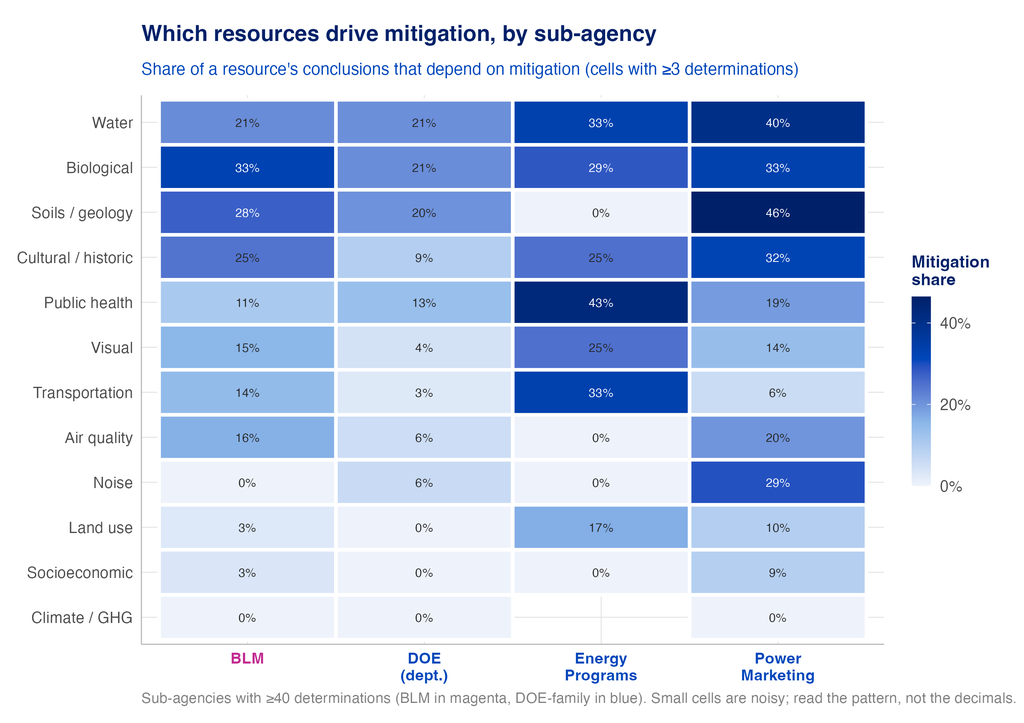

Figure 12: Mitigation-dependent share by sub-agency and resource area, for sub-agencies with at least 40 determinations. Darker = a larger share of that resource’s conclusions depend on mitigation. Small cells are noisy.

### Significance by clean-energy technology

The kind of project matters as much as the agency. Classifying each project by its primary technology (from the dataset’s project-type field) lets us ask which technologies most often need mitigation to stay below the line (Figure 13).

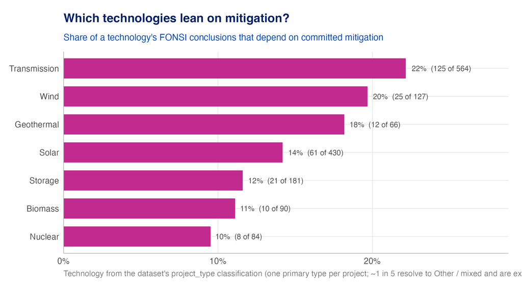

**Transmission and wind lean hardest on mitigation.** Linear corridors and turbine sites touch habitat, viewsheds, and cultural resources that repeatedly need committed measures to reach a not-significant finding. Solar and storage sit lower, closer to the corpus average.

### Enforceability of committed mitigation

“Mitigated” only means something if the measures are actually required. The extraction flags whether each mitigated conclusion is tied to an enforceable permit condition or is committed only in the document’s text. Figure 14 shows the split by resource.

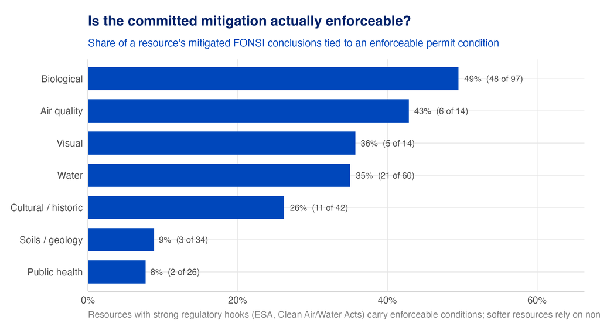

Figure 14: Share of a resource’s mitigated FONSI conclusions tied to an enforceable permit condition (versus committed only in the document text). Reported descriptively — an unmatched conclusion may still be enforced through channels the extraction doesn’t capture.

## EIS analysis

The FONSI track shows how agencies stay below the significance line. The EIS track is its mirror, the above-the-line record of where impacts actually cross it. It runs the identical extraction-and-validation machinery on the EIS corpus (same controlled vocabulary, per-resource grain, and AI-human reviewed held-out test) and adds three EIS-only fields the FONSI side doesn’t need: which alternative a finding attaches to, why the impact is significant, and how it reaches the resource.

The decarbonization EIS corpus is the larger of the two — 753 projects. Not all carry usable findings: significance sections were retrieved for 536, of which 506 yielded at least one determination (Figure 15). Unlike the FONSI track, the EIS analysis covers all agencies, not just BLM + DOE: it is purely descriptive (which resources cross the line) and never uses a project’s decision date, so projects without a firm date are kept rather than dropped. On that basis it rests on 506 projects (1,082 documents) carrying 13,240 distinct significance determinations — of which 2,198 land above the line, including 698 judged significant and unavoidable, impacts mitigation cannot erase.

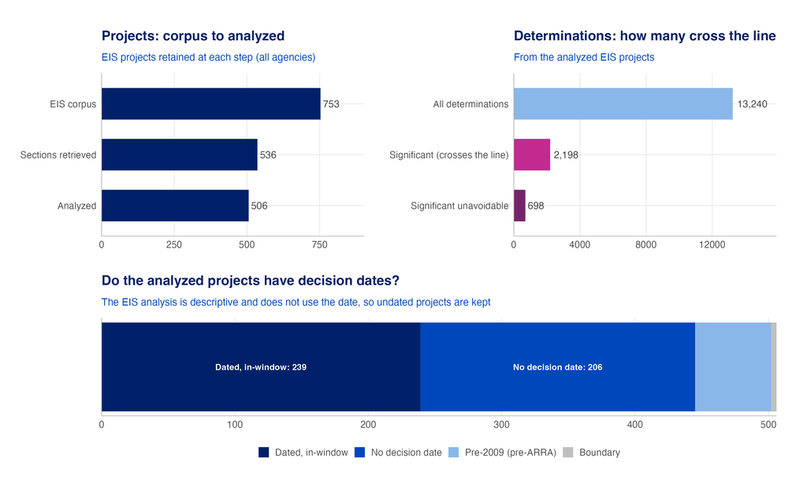

Figure 15: How the 753-project EIS corpus narrows to the analyzed set (top left): 536 had significance sections retrieved, 506 yielded a determination. Those projects produced 13,240 determinations, of which 2,198 are significant (cross the line) and 698 significant-unavoidable (top right). Of the 506 analyzed projects, only 239 have a firm in-window decision date — the analysis keeps the undated ones because it never uses the date (bottom).

**TipKey takeaways (EIS track)**

- **Visual impacts cross the line most.** Viewshed conclusions are judged significant more often than any other resource (~33% of visual determinations), and they most often reach significant and unavoidable; a changed landscape usually cannot be mitigated back.
- **Resources split into two shapes.** Some are managed below the line (soils/geology, water, and public health are routinely mitigated to “not significant” and rarely cross); others cross over (visual, land use, and air quality break through more often than they are mitigated below it).
- Magnitude, protected resources, and cumulative effects are the dominant reasons a call is significant, and roughly a third of significant findings rest on cumulative pathways, not the project’s direct footprint alone (impact-pathway rows are tallied per sub-finding and are not mutually exclusive, so they sum to more than the 2,198 class-level determinations).

### EIS extraction accuracy

The EIS pipeline was graded exactly as the FONSI one: two reviewers coded a stratified 400-window sample, a third adjudicated, and 30% was held out as an untouched test. The scores are lower across the board — the EIS task is harder, and the report treats it accordingly.

Table 3: EIS extraction accuracy versus the AI-human reviewed gold set, full sample and held-out test. Lower than the FONSI track — the above-the-line distinctions are genuinely finer.

| What the pipeline is scored on | All 400 | Held-out test |
| --- | --- | --- |
| Finds a determination (per passage) | 0.86 | 0.83 |
| Assigns the right resource | 0.72 | 0.68 |
| Gets the significance class right | 0.67 | 0.69 |
| Flags mitigation-dependence | 0.61 | 0.70 |
| Identifies the regulatory threshold | 0.55 | 0.62 |

Scores are F1 (0–1), except the threshold row, which is accuracy. Held-out = the 30% of the gold set the pipeline never influenced.

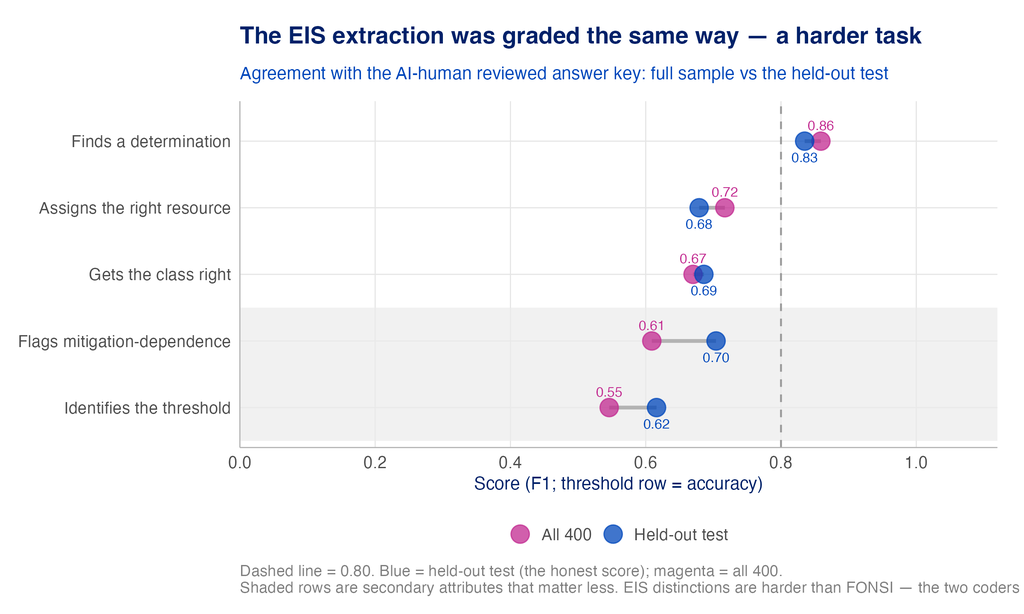

Figure 16: EIS agreement with the AI-human reviewed answer key: full sample (magenta) vs held-out test (blue). The shaded bottom two rows are secondary attributes that matter less to the findings (as in the FONSI figure). Every score sits below the FONSI equivalent — the above-the-line call is a finer judgment (the two independent AI coders themselves agreed only ~58% on the class).

### Which resources cross the line

Within EISs, the interesting determinations are the ones that break above the line. Those come in two degrees of severity:

- Significant adverse: the impact is significant, but the agency does not declare it beyond repair, and committed measures may still reduce it.
- Significant unavoidable: the impact is significant and cannot be brought below the line even with mitigation. This is the more severe call, and the one that most constrains a project.

Figure 17 ranks each resource by how often its EIS conclusions are judged significant, splitting the two degrees (least severe on the left, most severe on the right).

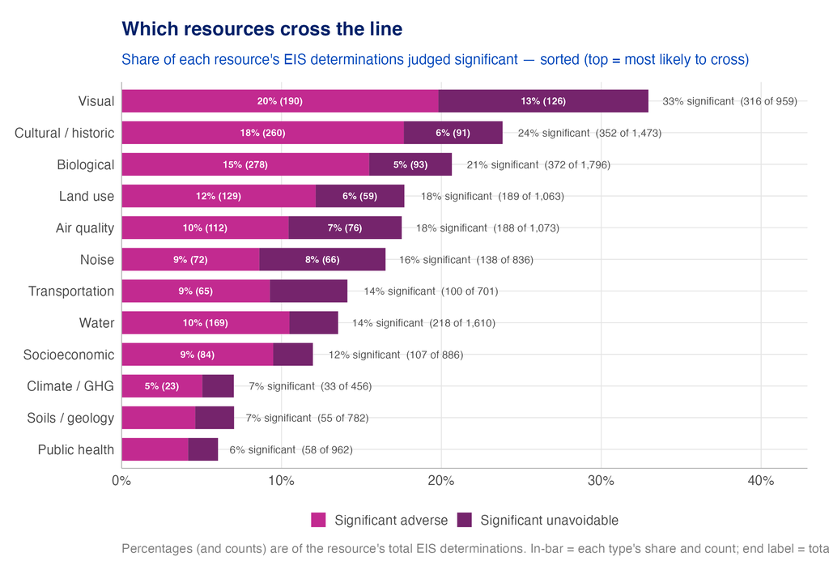

Figure 17: Share of each resource’s EIS determinations judged significant, sorted (top = most likely to cross the line). Each percentage (and count) is of the resource’s total EIS determinations: the in-bar labels split significant-adverse (lighter, left) from significant-unavoidable (darker, right); the end label gives the combined significant share and count (e.g. visual = 316 of 959, of which 126 are unavoidable).

Visual (33%), Cultural / historic (24%), Biological (21%), and Land use (18%) are the resources most likely to cross into significance. **Visual stands alone at the top,** the clearest case of an impact that, once significant, tends to stay that way.

### Significant and unavoidable impacts

The starkest determinations are the significant and unavoidable ones, where the agency concludes the impact is real, material, and cannot be mitigated below the line. These are the true limits on a decarbonization project. Figure 18 counts them by resource: each bar is the number of distinct significant-and-unavoidable determinations (one per document × resource) for that resource, across the analyzed EIS projects.

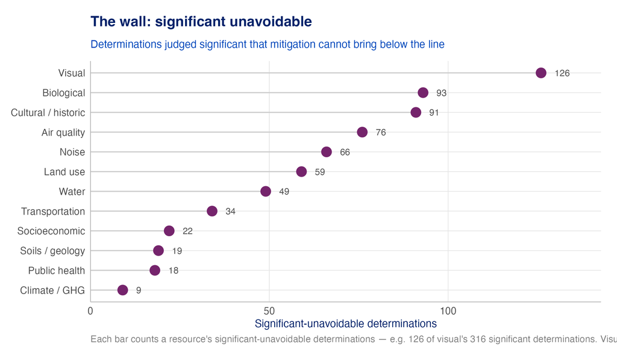

Figure 18: Count of significant-unavoidable determinations by resource — the darker (right-hand) segments of the previous figure, now counted. Visual’s 126 means 126 of its 316 significant determinations were judged unavoidable; biological, cultural, and air quality follow. These are the impacts that remain significant even after mitigation.

**Visual impacts dominate the significant-and-unavoidable findings.** A wind farm on a ridgeline or a transmission corridor across open country changes a landscape in ways no mitigation fully undoes, so viewshed conclusions reach unavoidable more than any other resource. Biological, cultural, and air-quality impacts follow, where habitat loss, historic-setting change, or a regional pollutant burden can exceed what on-site measures can offset. Table 4 shows what these look like in the agencies’ own words.

Table 4: Representative significant-and-unavoidable determinations, verbatim from the EIS, ordered from the resources that hit the wall most often.

| Significant-unavoidable finding, in the agency's words |
| --- |
| Visual |
| With mitigation, impacts to scenic vistas would remain adverse and unavoidable (VIS-1). |
| Aesthetics impacts are listed in Table ES-2 as significant and unavoidable even with mitigation. |
| Biological |
| The proposed project would result in major unavoidable adverse effects on desert tortoise habitat. |
| Potential panel and infrastructure collision risks to special-status birds (Impact 3.3.5a) would be significant and unavoidable. |
| Cultural / historic |
| The project would cause direct and indirect adverse change to the significance of historic properties. |
| Remaining significant (or potentially significant) unavoidable adverse impacts were identified for cultural resources. |
| Air quality |
| Unavoidable air quality impacts due to dust generated during site preparation and construction. |
| Following mitigation, PM10 emissions would remain significant and unavoidable for the Proposed Action. |
| Noise |
| Noise associated with Alternative 4 operations is identified as a long-term, unavoidable impact. |
| Vibration impacts to humans would remain significant and unavoidable during blasting at Copco 1. |
| Land use |
| Long-term loss of grazing allotments is identified as an unavoidable adverse impact. |
| Long-term loss of grazing allotments is identified as an unavoidable adverse land use impact. |
| Water |
| Cumulative impact on watersheds is identified as an unavoidable adverse water resources effect for all action alternatives. |
| Cumulative impact on watersheds is listed as an adverse environmental effect that cannot be avoided for all action alternatives. |
| Transportation |
| Traffic associated with Alternative 4 operations is identified as a long-term, unavoidable impact. |
| Long-term, unavoidable traffic impacts were identified as associated with Alternative 4 operations. |
| Socioeconomic |
| Potential short-term and long-term impacts on current land uses would produce associated social and economic impacts. |
| Potential for short-term construction and long-term impacts on current land uses and associated social and economic resources. |
| Soils / geology |
| Impacts to paleontological resources under this alternative are similar to the Proposed Action and would be significant under criterion P-1. |
| Unavoidable adverse impacts associated with the Proposed Action and Maximum Development Alternative include effects on topography, geology and soils. |
| Public health |
| Worker injuries or death are considered unavoidable adverse impacts given the hazardous nature, complexity, and scale of the Project. |
| Project-induced currents or shocks would create hazards to the public, listed as a significant unmitigable impact despite grounding measures. |
| Climate / GHG |
| Significant and unmitigable impacts from cumulative GHG emissions are identified for the Proposed CRS and all alternative sites. |
| Removing dams or developing fish passage could increase GHG emissions from non-renewable alternate power sources despite mitigation measures. |

Verbatim from the model's per-determination rationale on significant-unavoidable conclusions.

### Breadth of significance within an EIS

The resource views above pool all EISs together. Stepping back to the document level asks a different question: when an EIS does cross the line, does it do so on one resource or many? Figure 19 answers it.

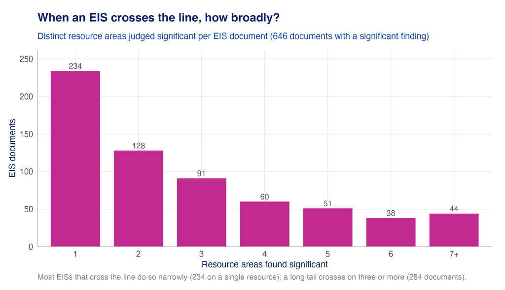

Figure 19: Distinct resource areas judged significant per EIS document, among the 646 documents with at least one significant finding. Most cross narrowly — 234 on a single resource — but a long tail crosses on three or more; a handful span the whole environmental slate.

Crossing the line is usually a focused event: over a third of EISs that cross do so on a single resource, and the median is two. But a meaningful minority — 284 documents — cross on three or more resources, and a few span nearly the entire environmental slate. (This counts only resource-area determinations; documents whose significant conclusion is stated project-wide, or not captured by the retrieval, sit outside it — see *Methods*.)

### FONSI versus EIS: two ways a resource crosses the line

Analyzing the two tracks separately pays off in one picture (Figure 20), which plots each resource by how often it is mitigated below the line (FONSIs, x-axis) against how often it crosses the line (EISs, y-axis). **The magenta resources are more likely to be judged significant than to be mitigated; the blue resources are the reverse.** (Both tracks are restricted to BLM + DOE here, so the two are measured on the same footing — FONSI coverage is only partial outside those agencies.)

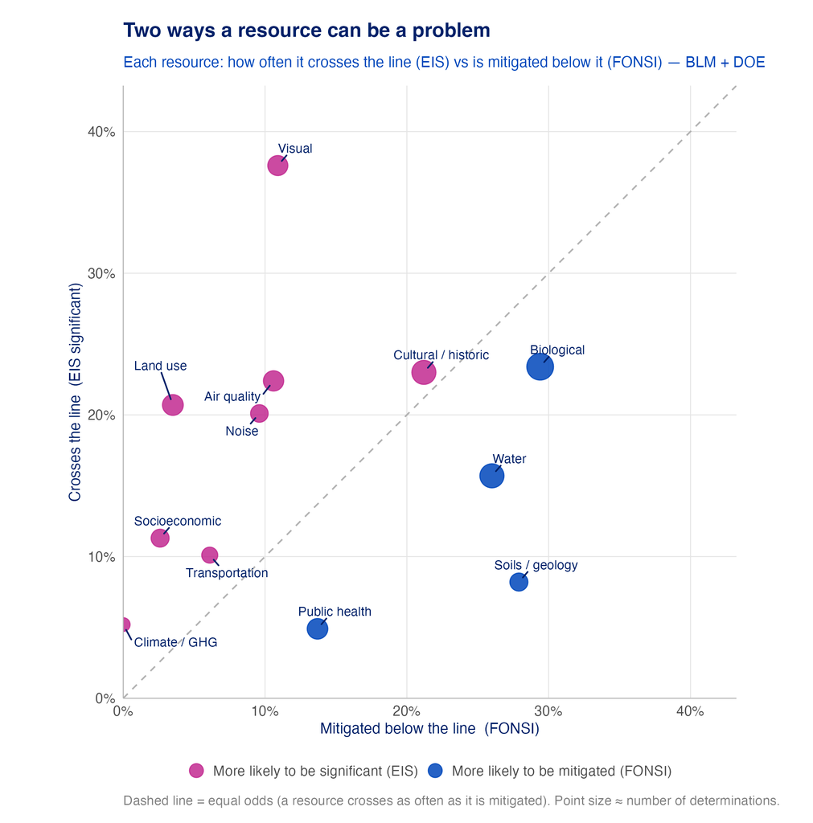

Figure 20: Each resource (BLM + DOE, so both tracks share a scope) plotted by how often it is mitigated below the line in FONSIs (x) versus how often it crosses into significance in EISs (y). The dashed diagonal is equal odds; the bottom legend gives the colors — magenta resources (above the line) are judged significant more often than mitigated, blue resources (below) the reverse. Point size ≈ determinations.

The split is the deliverable’s sharpest structural finding. Three shapes emerge. The magenta resources (visual, land use, and air quality) break above the line more often than they are mitigated below it; when these become a problem, agencies more often accept a significant finding than engineer their way under it, and visual is the extreme (within BLM + DOE it crosses ~38% of the time and is mitigated only ~11%). The blue resources (soils/geology, water, and public health) show the opposite, frequently mitigated in FONSIs and rarely crossing into significance, the impacts that committed measures reliably handle. Cultural / historic sits right on the line, crossing into significance about as often as it is mitigated below it (~23% vs ~21%), the one resource that genuinely straddles both sides.

### What makes an impact significant

For every above-the-line determination the extraction also records why it is significant. Figure 21 gives the dominant factors overall; Figure 22 is the fuller picture: where each factor bites, i.e. the resources each reason concentrates in.

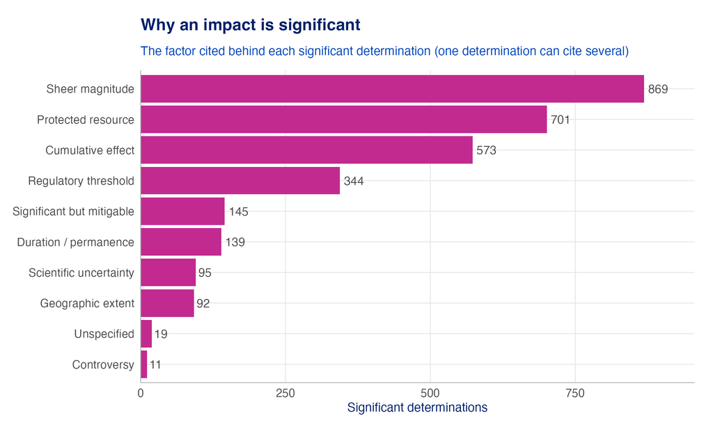

Figure 21: The dominant factor behind each significant determination. Sheer magnitude, a protected resource, and cumulative effects lead.

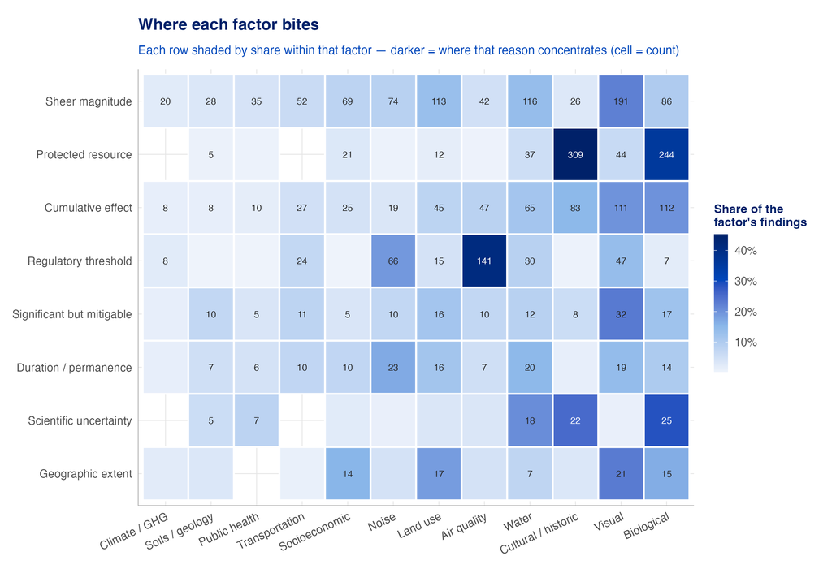

Figure 22: Where each factor bites. Each row is shaded by the share within that factor (not across the whole grid), so the darkest cells show where a reason concentrates; the cell number is the raw count. Sheer magnitude concentrates in visual, water, and land use; a protected resource in cultural and biological; a regulatory threshold in air quality and noise; cumulative effects in biological and visual.

Table 5: What each significance factor looks like in the EIS text — verbatim examples, ordered from the most common factor down.

| Significant finding, in the agency's words |
| --- |
| Sheer magnitude |
| The Pier 41 Alternative could result in major socioeconomic impacts. |
| The Build Alternative would result in significant impacts to visual resources. |
| Protected resource |
| Alternative E would result in significant impacts to cultural resources. |
| Significant impacts on Usual and Accustomed (U&A) fishing rights are identified. |
| Cumulative effect |
| The presence of the AEWP would add to a cumulative visual alteration, as discussed above. |
| Cumulative impacts to terrestrial ecology and aquatic resources are rated MODERATE to LARGE. |
| Regulatory threshold |
| VRM Class III objectives would not be met for this segment. |
| Greenhouse gas emissions cumulatively would exceed the applicable CEQ threshold. |
| Significant but mitigable |
| Significant but mitigable impacts to parade-ground vegetation from irrigation with reclaimed water. |
| Development activities would introduce intrusions that could unavoidably affect the visual landscape. |
| Duration / permanence |
| Long-term loss of grazing allotments is identified as an unavoidable adverse impact. |
| Short-term decreases in water clarity would have a significant adverse effect on recreation. |
| Scientific uncertainty |
| Population increase is possibly significant for Phase I, with impacts for future phases unknown. |
| Inadvertent damage to paleontological resources not identified by monitors could occur during excavation. |
| Geographic extent |
| The Western Alternative would result in 14.5 miles of significant, long-term visual impacts. |
| Land developed for renewable energy facilities would no longer be available for livestock grazing. |
| Controversy |
| The proposed transmission line would conflict with the City of Yuma's resolution opposing the line, resulting in an unavoidable significant impact on the city's land planning policy. |
| The proposed transmission line would conflict with a City of Yuma resolution opposing a 500-kV line in that location, resulting in a significant impact with no identified mitigation measures. |

Verbatim from the model's per-determination rationale, grouped by the dominant significance factor it recorded.

**Findings attach mostly to the proposed action.** About half of significant determinations name a specific alternative; where they do, the proposed action dominates, with named build and no-action alternatives carrying the rest. Significance is overwhelmingly a judgment about what the applicant proposed, not about the alternatives weighed against it.

### Variation by agency

Because the EIS track spans every lead agency (not just BLM + DOE), we can ask whether some agencies cross the line more than others. They do — and the pattern tracks the kind of project each agency runs (Figure 23).

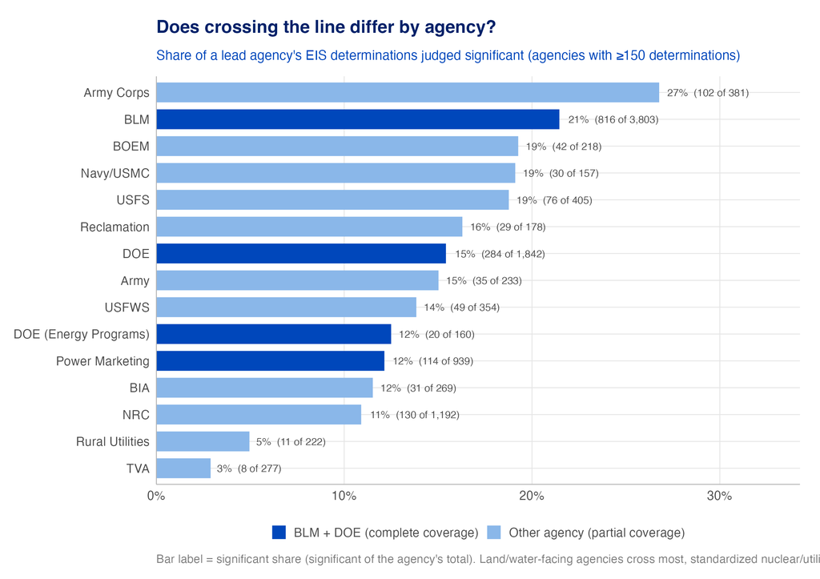

The spread is real — from Army Corps (27%) at the top down to TVA (3%). Land- and water-facing agencies — the Army Corps and BLM — cross into significance most often, which fits their portfolios (dredge-and-fill permits, public-land rights-of-way with visual and habitat exposure). The utility-service programs — the Rural Utilities Service and TVA — cross least, consistent with routine utility infrastructure on already-developed land and corridors. BLM and the DOE family remain the only agencies with complete coverage; the others are shown for context.

### Significance by clean-energy technology

The most decision-relevant cut for a decarbonization portfolio is the technology. Classifying each project by its primary technology (from the dataset’s project-type field), Figure 24 ranks how often each crosses the line, and Figure 25 shows where each technology’s distinct “significance signature” lies.

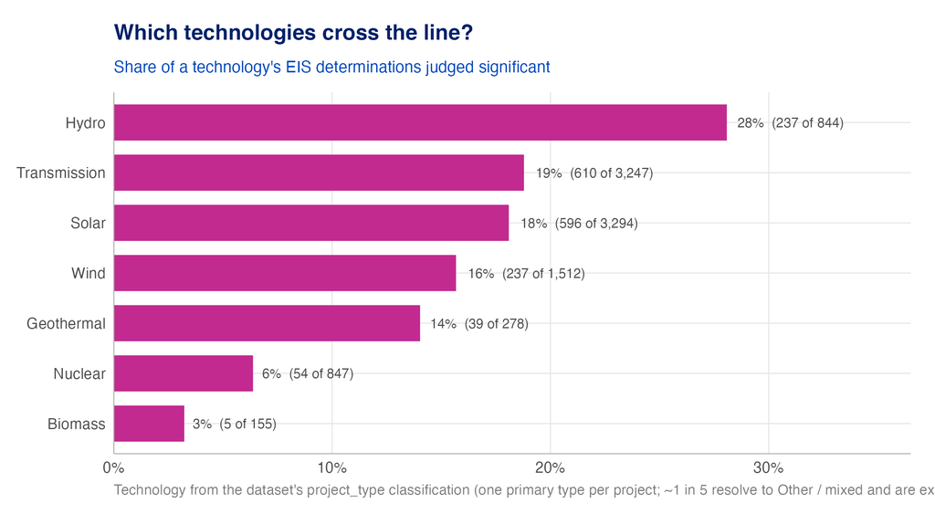

Figure 24: Share of a technology’s EIS determinations judged significant. Technology is derived from the dataset’s project-type classification; about 1 in 5 projects resolve to an ‘Other / mixed’ bucket and are excluded, so read this for the named technologies.

**Hydropower crosses the line most** (28%), as dams carry aquatic and water impacts that are hard to avoid, followed by transmission and solar (~19% and ~18%). **Nuclear crosses least among the large technologies** (6%), consistent with siting on already-industrial land under highly prescribed review. But the rate is only part of the picture; the resources each technology hits are distinct:

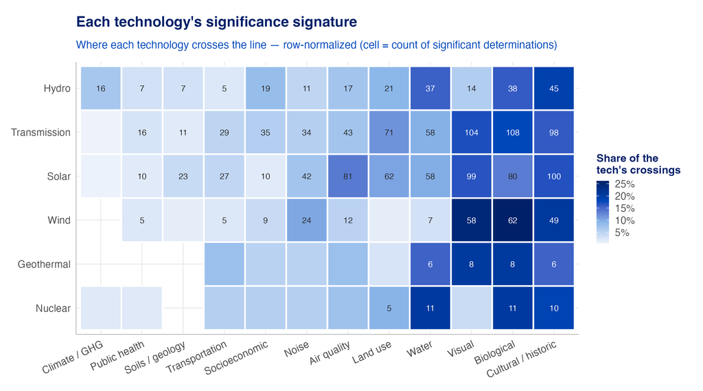

### Significant but reducible impacts

Not every above-the-line finding is a hard stop. One of the significance factors the extraction records is mitigable: the impact crosses the line, but the agency notes that measures can still lessen it. This is the EIS analog of a mitigated FONSI, and Figure 26 shows where it occurs.

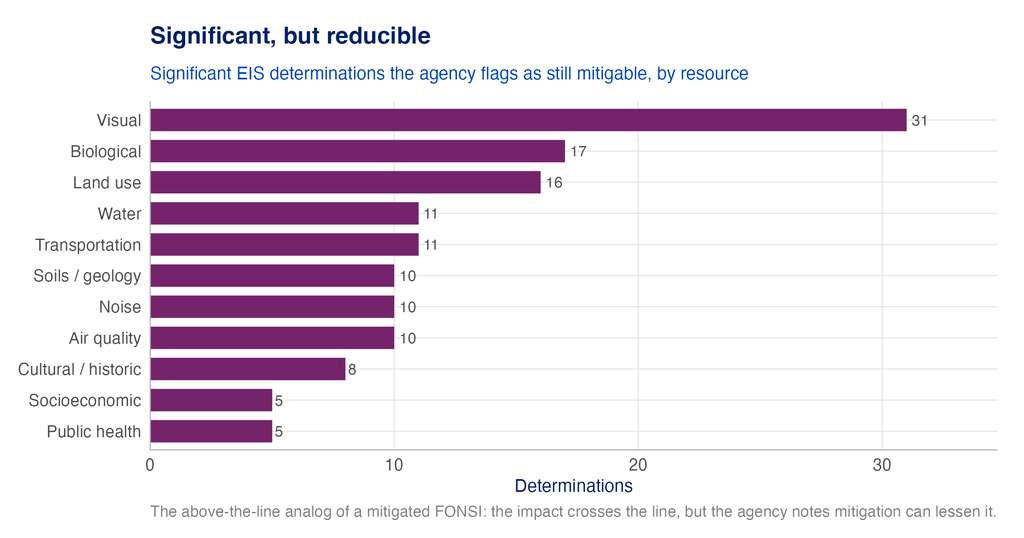

Figure 26: Significant EIS determinations the agency flags as still mitigable, by resource — the above-the-line counterpart to a mitigated FONSI.

Table 6: Representative significant-but-mitigable determinations, verbatim from the EIS.

| Significant-but-mitigable finding, in the agency's words |
| --- |
| Visual |
| Development activities would introduce intrusions that could unavoidably affect the visual landscape. |
| Biological |
| Significant but mitigable impacts to parade-ground vegetation from irrigation with reclaimed water. |
| Land use |
| Impact AG-1 permanent conversion of Important Farmland is mitigated via agricultural easement or land mitigation program. |
| Transportation |
| With the mitigation measures identified above, significant unavoidable transportation impacts are not expected. |
| Water |
| PA/FEIS Section 4.19 concludes mitigation measures would minimize but not eliminate residual groundwater level reductions from GSEP implementation. |
| Air quality |
| Combined regional projects together with Alternative 4's WTE plant would be a significant but mitigable cumulative impact to air quality. |
| Noise |
| Vibration impacts to humans would be significant near Copco 1 Dam during blasting, and Mitigation Measure NV-1 would not reduce these impacts below significance, remaining significant and unavoidable. |
| Soils / geology |
| Draining Copco No. 1 Reservoir could cause short-term significant bank instability at some private properties, but these effects would be mitigated. |

Verbatim from the model's rationale on determinations tagged with the 'mitigable' significance factor.

Tellingly, visual leads this list too: even the resource most likely to reach a significant-and-unavoidable finding sometimes admits partial mitigation (screening, siting adjustments), just not enough to drop below the line. These cases are the closest the EIS record comes to the mitigated-FONSI story — significant enough to require a full statement, but not beyond the reach of committed measures.

## Reproducibility

Every number and figure in this report is regenerated by committed code, run from the repository root in the `nepa` conda environment. The two significance-extraction passes (FONSI and EIS) are billable LLM prerequisites: run once, then the deterministic analysis reads their outputs.

```bash
# 0. framework regime + corpus + cohorts (deterministic)
conda run -n nepa python phase2/code/deliverable02/00_resolve_framework_regime.py
conda run -n nepa python phase2/code/deliverable02/01_build_d2_inventory.py

# 1. FONSI extraction — billable Anthropic batch (Sonnet 5); --dry-run for cost only
conda run -n nepa python phase2/code/deliverable02/02_extract_fonsi_significance.py \
  --batch-run --model claude-sonnet-5

# 2. EIS extraction — billable Anthropic batch (Sonnet 5); ~21.9k windows (~$110–115)
conda run -n nepa python phase2/code/deliverable02/04_extract_eis_significance.py \
  --sample 0 --batch-run --model claude-sonnet-5

# 3. validate both tracks against the AI-human reviewed gold (held-out test)
conda run -n nepa python phase2/code/deliverable02/05_validate_significance.py             # FONSI
conda run -n nepa python phase2/code/deliverable02/05_validate_significance.py --track eis  # EIS

# 4. analysis tables + figures (writes the CSVs/PNGs this report reads)
Rscript phase2/code/deliverable02/06_create_figures.R

# 5. render
quarto render phase2/reports/deliverable02.qmd
```

Outputs land in `phase2/data/analysis/deliverable02/` (determination parquets, validation metrics) and `phase2/output/deliverable02/analysis/` (CSV tables + figures); the answer keys (AI-coded, human-adjudicated) live under `…/deliverable02/gold/`. Schemas for every emitted parquet are documented in `phase2/notes/deliverable02/data_dictionary.md`, and full provenance — input/output paths, row counts, content hashes, model, prompt/schema versions — is recorded in `significance_run_manifest.parquet`.

## Footnotes

[^1]: The answer key was built by two independent AI coding agents (Claude and Codex), each labeling every passage in the sample on its own; a human analyst then audited the two sets — values the coders agreed on were accepted, and every disagreement (over half the rows, on at least one field) was adjudicated by hand. “AI-human reviewed” is shorthand for that process: AI-coded, human-audited.
[^2]: A small number of resource-level determinations (23 of the 1,990) are classified significant on their face — typically language about a rejected alternative or a resource-specific finding inside the supporting EA. They are held out of the three-outcome breakdown that follows so its counts reconcile with the resource map and figures.